# ee

My GitHub Link - https://github.com/raqeebshaikh/powerplant_analysis

Interactive Map Global Power Plant - https://raw.githack.com/raqeebshaikh/powerplant_analysis/main/Global_PowerPlants.html

Interactive Map India For Above Map - https://raw.githack.com/raqeebshaikh/powerplant_analysis/main/IN_PowerPlants.html

```python
import matplotlib.pyplot as plt
import pandas as pd
import os
pd.options.display.float_format = '{:.2f}'.format
import pandas as pd
import matplotlib.pyplot as plt
import pandas as pd
import matplotlib.pyplot as plt
import numpy as np
import matplotlib.colors as mcolors
import pandas as pd
from keplergl import KeplerGl
from bs4 import BeautifulSoup
```

```python
all_files = []
for x,y,z in os.walk('./Temperature_And_Precipitation_Cities_IN/'):
    for file in z:
        file_path = os.path.join(x,file)
        all_files.append(file_path)
```

```python
GlobalPowerPlantDataset = pd.read_csv('powerplants (global) - global_power_plants.csv')
power_statuion_europe = pd.read_excel('./scigrid-conference-eu-data-only/vertices_eu_power_160718.csvdata.xlsx')
```

# Analysis on India

```python
IndiaPowerPlants = GlobalPowerPlantDataset[GlobalPowerPlantDataset['country_long'] == 'India']
```

```python
print(f'Total Power Plants In India : {len(IndiaPowerPlants)}')
```

```
Total Power Plants In India : 1589
```

```python
types_of_powerplant_india  = IndiaPowerPlants.groupby('primary_fuel').agg({'name of powerplant':['count'],'capacity in MW': ['sum']}).reset_index()
```

```python
types_of_powerplant_india['percentage_contribution'] = (types_of_powerplant_india[('capacity in MW', 'sum')] / types_of_powerplant_india[('capacity in MW', 'sum')].sum()) * 100
```

```python
types_of_powerplant_india.sort_values(by=('capacity in MW', 'sum'), ascending=False)
```

|  | primary_fuel | name of powerplant count | capacity in MW sum | percentage_contribution |
| --- | --- | --- | --- | --- |
| 1 | Coal | 253 | 204919.22 | 64.83 |
| 3 | Hydro | 233 | 45561.47 | 14.41 |
| 6 | Solar | 851 | 25549.10 | 8.08 |
| 2 | Gas | 68 | 24947.51 | 7.89 |
| 4 | Nuclear | 9 | 8780.00 | 2.78 |
| 7 | Wind | 108 | 3647.15 | 1.15 |
| 5 | Oil | 17 | 1680.84 | 0.53 |
| 0 | Biomass | 50 | 1003.26 | 0.32 |

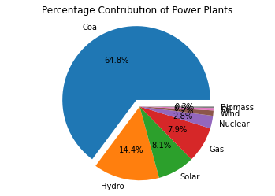

```python
types_of_powerplant_india.sort_values('percentage_contribution',ascending=False,inplace=True)
labels = types_of_powerplant_india['primary_fuel']
sizes = types_of_powerplant_india['percentage_contribution']
explode = (0.1, 0, 0, 0, 0, 0, 0, 0)
fig1, ax1 = plt.subplots()
ax1.pie(sizes, explode=explode, labels=labels, autopct='%1.1f%%', startangle=0)
ax1.axis('equal')

plt.title('Percentage Contribution of Power Plants')
plt.show()
```

### India is Dominated by Coal for Electricity Generation with 64.8% Generation from Coal

#### Total Coal Plant's are around 253

##### 1. It's MW Generation is More.

##### 2. It's means More Power is generated with less Plants.

##### 3. Coal generation is Cost effective.

```python
IndiaPowerPlants['primary_fuel'].unique()
```

```
array(['Solar', 'Coal', 'Wind', 'Gas', 'Hydro', 'Biomass', 'Oil',
       'Nuclear'], dtype=object)
```

#### Tops 5 Power Plants in India based on capacity in MW

```python
IndiaPowerPlants.sort_values('capacity in MW',ascending=False).head(5)[['country code', 'country_long', 'name of powerplant', 'capacity in MW',
       'primary_fuel', 'secondary fuel']]
```

|  | country code | country_long | name of powerplant | capacity in MW | primary_fuel | secondary fuel |
| --- | --- | --- | --- | --- | --- | --- |
| 15586 | IND | India | VINDH_CHAL STPS | 4760.00 | Coal | Oil |
| 14929 | IND | India | MUNDRA TPP | 4620.00 | Coal | Oil |
| 14930 | IND | India | MUNDRA UMPP | 4000.00 | Coal | Oil |
| 15312 | IND | India | SASAN UMPP | 3960.00 | Coal | Oil |
| 15473 | IND | India | TIRORA TPP | 3300.00 | Coal | Oil |

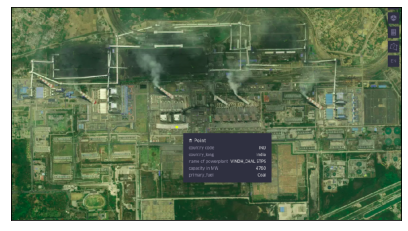

```python
IN_PowerPlant = plt.imread('./Photos/IN_large_coal.png')
plt.figure(figsize=(7, 20))
plt.imshow(IN_PowerPlant)
plt.xticks([])
plt.yticks([])
plt.show()
```

## Tops 5 Solar Power Plants in India based on capacity in MW

```python
IndiaPowerPlants[IndiaPowerPlants['primary_fuel'] == 'Solar'].sort_values('capacity in MW',ascending=False).head(5)[['country code', 'country_long', 'name of powerplant', 'capacity in MW',
       'primary_fuel', 'secondary fuel']]
```

|  | country code | country_long | name of powerplant | capacity in MW | primary_fuel | secondary fuel |
| --- | --- | --- | --- | --- | --- | --- |
| 14774 | IND | India | Kamuthi Solar Power Plant | 648.00 | Solar | NaN |
| 14252 | IND | India | BhSP3 | 560.00 | Solar | NaN |
| 15052 | IND | India | NPKSP} Greenko | 500.00 | Solar | NaN |
| 14720 | IND | India | KUMSP} Greenko | 500.00 | Solar | NaN |
| 14240 | IND | India | BhSP1 | 420.00 | Solar | NaN |

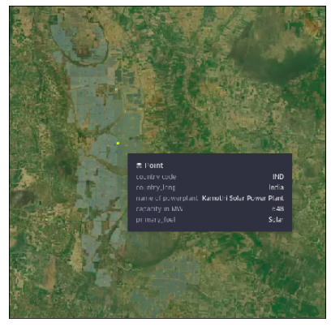

```python
IN_PowerPlant = plt.imread('./Photos/IN_large_solar.png')
plt.figure(figsize=(7, 20))
plt.imshow(IN_PowerPlant)
plt.xticks([])
plt.yticks([])
plt.show()
```

#### Location Screen Shoot based on The coordinates of Dataset. Above is the Largest solar power plant in India (648 MW)

#### Based on above data Largest Solar Plant has capacity of 648 MW and in Located in Tamil Nadu (Kamuthi Solar Power Plant)

```python
megawatt_power_generated_by_coal_plants = types_of_powerplant_india[types_of_powerplant_india['primary_fuel'] == 'Coal'].iloc[0]['capacity in MW']['sum']
megawatt_power_generated_by_solar_plants = types_of_powerplant_india[types_of_powerplant_india['primary_fuel'] == 'Solar'].iloc[0]['capacity in MW']['sum']
solar_power_plant_count = types_of_powerplant_india[types_of_powerplant_india['primary_fuel'] == 'Solar'].iloc[0]['name of powerplant']['count']
solar_plant_to_increase_power_generation_percent = megawatt_power_generated_by_coal_plants/megawatt_power_generated_by_solar_plants
```

```python
new_solar_power_plants = solar_power_plant_count * solar_plant_to_increase_power_generation_percent
print(f"New Solar Power Plants to Match Coal Power Generation : {int(new_solar_power_plants)}")
```

```
New Solar Power Plants to Match Coal Power Generation : 6825
```

#### Limitation of Solar Power is we have Certain Hours of Sunlight to Power our Infracture. Therefore it will not be possible to completely switch to Solar Energy.

## Synergizing Sustainable Energy

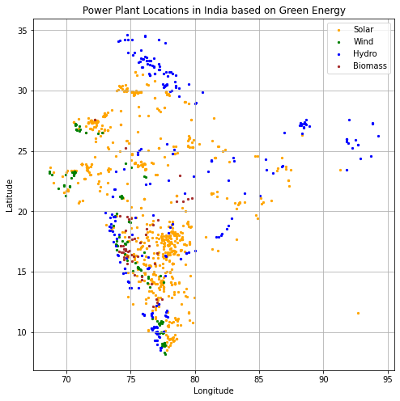

```python
Renuable_India_PowerPlants = IndiaPowerPlants[IndiaPowerPlants.primary_fuel.isin(['Solar', 'Wind', 'Hydro', 'Biomass'])]
filtered_data = Renuable_India_PowerPlants[['latitude', 'longitude', 'primary_fuel']]
unique_fuels = filtered_data['primary_fuel'].unique()
fuel_colors = {'Solar':'orange', 'Wind':'green', 'Hydro':'blue', 'Biomass':'brown'}
plt.figure(figsize=(8, 8))

for fuel in unique_fuels:
    fuel_data = filtered_data[filtered_data['primary_fuel'] == fuel]
    color = fuel_colors[fuel]
    plt.scatter(
        fuel_data['longitude'],
        fuel_data['latitude'],
        marker='o',
        s=5,
        alpha=1,
        color=color,
        label=fuel
    )

plt.title('Power Plant Locations in India based on Green Energy')
plt.xlabel('Longitude')
plt.ylabel('Latitude')
plt.grid(True)
plt.legend()
plt.show()
```

##### The chart provided illustrates the presence of power plants using different energy sources, specifically Hydro, Wind, Solar, and Biomass. However, it's important to understand the dynamic relationship between these energy sources.

##### Hydro power plants are known for their ability to store water below a reservoir during periods of excess energy production, often during the daytime. This stored water represents potential energy that can be converted into kinetic energy when needed.

##### To optimize the utilization of this potential energy, Wind, Solar, and Biomass power sources play a crucial role. During the daytime, when energy production from these sources is abundant, they can collectively power the Hydro project. This surplus energy can be used to pump water back to the top of the reservoir, effectively converting kinetic energy into potential energy. This process essentially "recharges" the Hydro project, making it ready to generate electricity during periods of high demand, such as at night.

## Indias Power Plant Distribution Based on Renewable to Non Renewable Energy

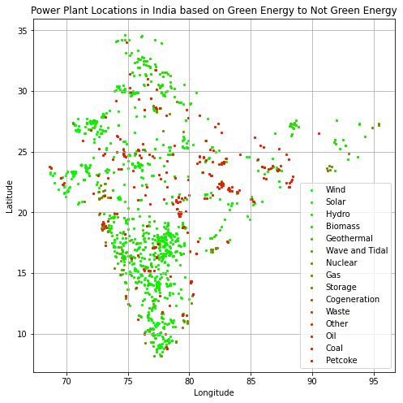

```python
filtered_data = IndiaPowerPlants[['latitude', 'longitude', 'primary_fuel']]

unique_fuels = filtered_data['primary_fuel'].unique()

unique_fuels = [
    'Wind',
    'Solar',
    'Hydro',
    'Biomass',
    'Geothermal',
    'Wave and Tidal',
    'Nuclear',
    'Gas',
    'Storage',
    'Cogeneration',
    'Waste',
    'Other',
    'Oil',
    'Coal',
    'Petcoke'
]

# Generate a colormap that transitions from green to red
n = len(unique_fuels)
colors = [(i/n, 1-i/n, 0) for i in range(n)]
cmap = mcolors.LinearSegmentedColormap.from_list('green_to_red', colors, N=n)

# Assign colors to each fuel
fuel_colors = {fuel: cmap(i/n) for i, fuel in enumerate(unique_fuels)}

# Create a scatter plot with random colors for each fuel type
# plt.figure(figsize=(18, 8))
plt.figure(figsize=(8, 8))

for fuel in unique_fuels:
    fuel_data = filtered_data[filtered_data['primary_fuel'] == fuel]
    color = fuel_colors[fuel]
    plt.scatter(
        fuel_data['longitude'],
        fuel_data['latitude'],
        marker='o',
        s=5,
        alpha=1,
        color=color,
        label=fuel
    )

plt.title('Power Plant Locations in India based on Green Energy to Not Green Energy')
plt.xlabel('Longitude')
plt.ylabel('Latitude')
plt.grid(True)
plt.legend()
plt.show()
```

#### Based on above data India has lots of Renewable Energy with Very Less Non Renewable Energy Power Plants But Power is generated more from Non Renewable sources.

```python
IndiaPowerPlants['secondary fuel'].unique()
```

```
array([nan, 'Oil', 'Cogeneration', 'Gas'], dtype=object)
```

```python
FilteredData = IndiaPowerPlants
map_1 = KeplerGl(height=600)
map_1.add_data(data=FilteredData, name='Power Plants')
map_1.save_to_html(data={'FilteredData': FilteredData}, config=None, file_name='IN_PowerPlants.html')
```

```
User Guide: https://docs.kepler.gl/docs/keplergl-jupyter
Map saved to IN_PowerPlants.html!
```

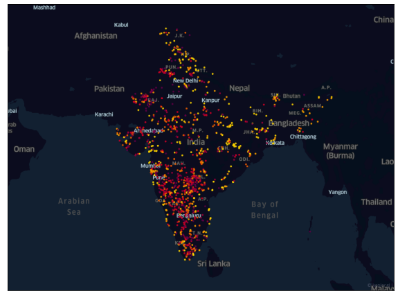

```python
IN_PowerPlant = plt.imread('./Photos/IN_PowerPlants.png')
plt.figure(figsize=(10, 10))
plt.imshow(IN_PowerPlant)
plt.xticks([])
plt.yticks([])
plt.show()
```

Interactive Link For Above Map - https://raw.githack.com/raqeebshaikh/powerplant_analysis/main/IN_PowerPlants.html

# Global Power Plant Analysis

```python
GlobalPowerPlantDataset.sort_values('capacity in MW', ascending = False).head(5)[['country code', 'country_long', 'name of powerplant', 'capacity in MW',
       'primary_fuel', 'secondary fuel']]
```

|  | country code | country_long | name of powerplant | capacity in MW | primary_fuel | secondary fuel |
| --- | --- | --- | --- | --- | --- | --- |
| 8453 | CHN | China | Three Gorges Dam | 22500.00 | Hydro | NaN |
| 5137 | CHN | China | Baihetan Dam | 13050.00 | Hydro | NaN |
| 8755 | CHN | China | Xiluodu | 12600.00 | Hydro | NaN |
| 19603 | RUS | Russia | Surgutskaya GRES-2 | 8865.00 | Gas | NaN |
| 34668 | VEN | Venezuela | Simon Bolivar (Guri) | 8851.00 | Hydro | NaN |

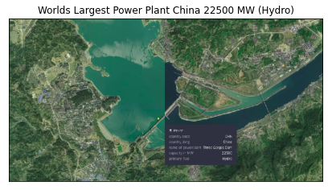

```python
IN_PowerPlant = plt.imread('./Photos/Globe_large_hydro.png')
plt.figure(figsize=(7, 20))
plt.imshow(IN_PowerPlant)
plt.xticks([])
plt.yticks([])
plt.title("Worlds Largest Power Plant China 22500 MW (Hydro)")
plt.show()
```

### Power Plant Distribution Based on Capacity in MW across Globe.

#### China Has largest Power Plants interestingly those is Hydro which are Green Energy

### Total Types of Power Plant across Globe

```python
GlobalPowerPlantDataset.primary_fuel.unique()
```

```
array(['Hydro', 'Solar', 'Gas', 'Other', 'Oil', 'Wind', 'Nuclear', 'Coal',
       'Waste', 'Biomass', 'Wave and Tidal', 'Petcoke', 'Geothermal',
       'Storage', 'Cogeneration'], dtype=object)
```

### Pie Chart Based on Count and Capacity

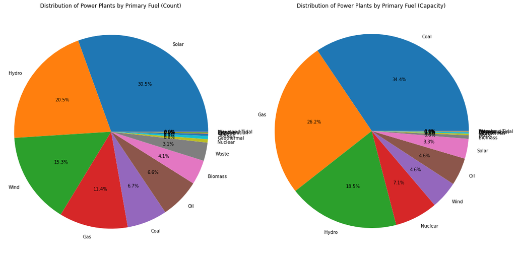

```python
import matplotlib.pyplot as plt

fig, axes = plt.subplots(1, 2, figsize=(16, 8))

# First Pie Chart - Distribution of Power Plants by Count
PowerPlantCount = GlobalPowerPlantDataset.groupby('primary_fuel').count()['name of powerplant'].reset_index().sort_values('name of powerplant', ascending=False)
axes[0].pie(PowerPlantCount['name of powerplant'], labels=PowerPlantCount['primary_fuel'], autopct='%1.1f%%', startangle=0)
axes[0].set_title("Distribution of Power Plants by Primary Fuel (Count)")
axes[0].axis('equal')

# Second Pie Chart - Distribution of Power Plants by Capacity
PowerPlantCapacity = GlobalPowerPlantDataset.groupby('primary_fuel').sum()['capacity in MW'].reset_index().sort_values('capacity in MW', ascending=False)
axes[1].pie(PowerPlantCapacity['capacity in MW'], labels=PowerPlantCapacity['primary_fuel'], autopct='%1.1f%%', startangle=0)
axes[1].set_title("Distribution of Power Plants by Primary Fuel (Capacity)")
axes[1].axis('equal')

plt.tight_layout()
plt.show()
```

### Map Shows Power Plant Distribution Based on Green to Not Green Energy

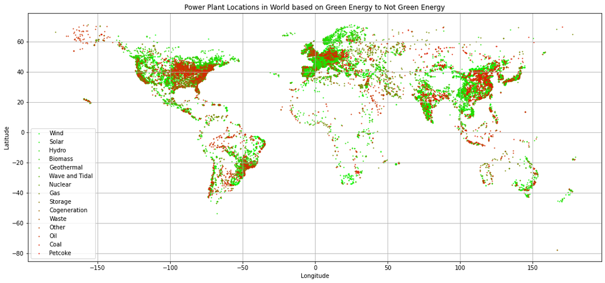

```python
filtered_data = GlobalPowerPlantDataset[['latitude', 'longitude', 'primary_fuel']]
unique_fuels = filtered_data['primary_fuel'].unique()
unique_fuels = [
    'Wind',
    'Solar',
    'Hydro',
    'Biomass',
    'Geothermal',
    'Wave and Tidal',
    'Nuclear',
    'Gas',
    'Storage',
    'Cogeneration',
    'Waste',
    'Other',
    'Oil',
    'Coal',
    'Petcoke'
]

n = len(unique_fuels)
colors = [(i/n, 1-i/n, 0) for i in range(n)]
cmap = mcolors.LinearSegmentedColormap.from_list('green_to_red', colors, N=n)


fuel_colors = {fuel: cmap(i/n) for i, fuel in enumerate(unique_fuels)}


plt.figure(figsize=(18, 8))
# plt.figure(figsize=(8, 8))

for fuel in unique_fuels:
    fuel_data = filtered_data[filtered_data['primary_fuel'] == fuel]
    color = fuel_colors[fuel]
    plt.scatter(
        fuel_data['longitude'],
        fuel_data['latitude'],
        marker='o',
        s=1,
        alpha=1,
        color=color,
        label=fuel
    )

plt.title('Power Plant Locations in World based on Green Energy to Not Green Energy')
plt.xlabel('Longitude')
plt.ylabel('Latitude')
plt.grid(True)
plt.legend()
plt.show()
```

##### Green Means Greener Energy like Wind, Solar, Hydro etc

##### Red Means Petcoke, Coal, Oil etc

##### It looks USA has a lot of Non Green Power Plants.

```python
GlobalPowerPlantDataset.groupby(['country_long'])['capacity in MW'].sum().sort_values(ascending = False).head(5)
```

```
country_long
China                      1415067.38
United States of America   1204638.05
India                       316088.55
Russia                      228220.05
Japan                       215365.85
Name: capacity in MW, dtype: float64
```

```python
GlobalPowerPlantDataset.groupby(['country_long'])['capacity in MW'].sum().sort_values(ascending = False).tail(5)
```

```
country_long
Guinea-Bissau   18.24
Antarctica       7.60
Palestine        7.60
Suriname         5.00
Saint Lucia      3.00
Name: capacity in MW, dtype: float64
```

```python
GlobalPowerPlantDataset[GlobalPowerPlantDataset['country_long'] == 'China'].groupby('primary_fuel').sum()['capacity in MW'].sort_values(ascending = False)
```

```
primary_fuel
Coal         955718.00
Hydro        259025.60
Gas           59774.50
Solar         54801.82
Wind          50990.36
Nuclear       33402.00
Oil            1329.00
Geothermal       26.10
Name: capacity in MW, dtype: float64
```

```python
GlobalPowerPlantDataset[GlobalPowerPlantDataset['country_long'] == 'United States of America'].groupby('primary_fuel').sum()['capacity in MW'].sort_values(ascending = False)
```

```
primary_fuel
Gas            546435.80
Coal           249149.10
Wind           104476.90
Nuclear        104233.10
Hydro          101656.90
Solar           37970.35
Oil             37143.40
Waste            9768.50
Biomass          5123.20
Geothermal       3889.20
Petcoke          2361.60
Cogeneration     1042.00
Storage           815.60
Other             572.40
Name: capacity in MW, dtype: float64
```

```python
GlobalPowerPlantDataset[GlobalPowerPlantDataset['country_long'] == 'India'].groupby('primary_fuel').sum()['capacity in MW'].sort_values(ascending = False)
```

```
primary_fuel
Coal      204919.22
Hydro      45561.47
Solar      25549.10
Gas        24947.51
Nuclear     8780.00
Wind        3647.15
Oil         1680.84
Biomass     1003.26
Name: capacity in MW, dtype: float64
```

```python
GlobalPowerPlantDataset[GlobalPowerPlantDataset['country_long'] == 'Japan'].groupby('primary_fuel').sum()['capacity in MW'].sort_values(ascending = False)
```

```
primary_fuel
Gas          53362.75
Oil          44120.20
Nuclear      42537.00
Coal         41513.00
Hydro        27439.00
Solar         5686.60
Geothermal     536.30
Wind           150.00
Waste           21.00
Name: capacity in MW, dtype: float64
```

```python
GlobalPowerPlantDataset[GlobalPowerPlantDataset['primary_fuel'] == 'Nuclear'].sort_values('capacity in MW',ascending = False)['capacity in MW']
```

```
16625   8212.00
21926   6000.00
20053   5900.00
20051   5900.00
10975   5460.00
          ...
101      370.00
18209    137.00
14395    100.00
19212     48.00
5258      20.00
Name: capacity in MW, Length: 195, dtype: float64
```

```python
FilteredData = GlobalPowerPlantDataset
map_1 = KeplerGl(height=600)
map_1.add_data(data=FilteredData, name='Power Plants')
map_1.save_to_html(data={'FilteredData': FilteredData}, config=None, file_name='Global_PowerPlants.html')
```

```
User Guide: https://docs.kepler.gl/docs/keplergl-jupyter
Map saved to Global_PowerPlants.html!
```

## Power Plants Across Globe (Kepler.gl)

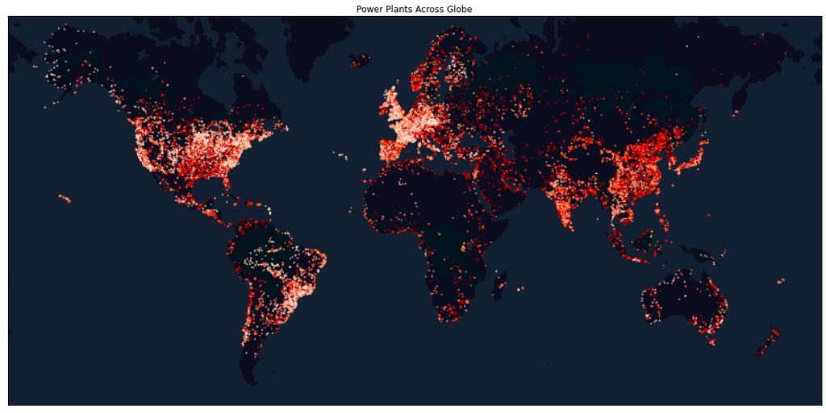

```python
Globe_PowerPlant = plt.imread('./Photos/Globe_PowerPlant.png')
plt.figure(figsize=(20, 10))
plt.imshow(Globe_PowerPlant)
plt.xticks([])
plt.yticks([])
plt.title('Power Plants Across Globe')
plt.show()
```

Interactive Map Global Power Plant - https://raw.githack.com/raqeebshaikh/powerplant_analysis/main/Global_PowerPlants.html

## Plots to Understand PowerPlant and the MW Capacity Across Globe

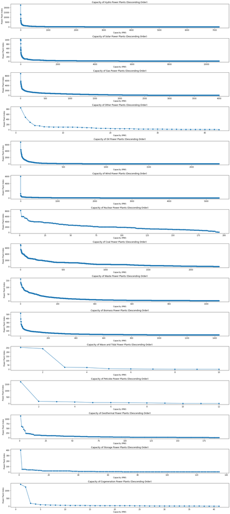

```python
import matplotlib.pyplot as plt

# Get unique primary fuel types
unique_fuels = GlobalPowerPlantDataset['primary_fuel'].unique()

# Create a figure with subplots
fig, axes = plt.subplots(len(unique_fuels), 1 , figsize=(18, 40))

# Loop through each unique primary fuel type
for i, fuel in enumerate(unique_fuels):
    # Filter the data for power plants with the current primary fuel and sort by capacity in MW
    fuel_data = GlobalPowerPlantDataset[GlobalPowerPlantDataset['primary_fuel'] == fuel].sort_values('capacity in MW', ascending=False)

    # Create a horizontal line plot for the current primary fuel
    axes[i].plot(range(1, len(fuel_data) + 1), fuel_data['capacity in MW'], marker='o', linestyle='-')
    axes[i].set_title(f"Capacity of {fuel} Power Plants (Descending Order)")
    axes[i].set_xlabel("Capacity (MW)")
    axes[i].set_ylabel("Power Plant Index")

# Adjust the layout
plt.tight_layout()

# Show the plots
plt.show()
```

## Selenium for Webscraping

https://www.accuweather.com/en/in/ahmednagar/2749633/daily-weather-forecast/2749633

[figure not shown]

```python
Globe_PowerPlant = plt.imread('./Photos/scraping.png')
plt.figure(figsize=(10, 10))
plt.imshow(Globe_PowerPlant)
plt.xticks([])
plt.yticks([])
plt.title('Power Plants Across Globe')
plt.show()
```

```python
from selenium import webdriver
from selenium.webdriver.firefox.options import Options
firefox_driver_path = 'geckodriver'
user_agent = "Mozilla/5.0 (Windows NT 10.0; Win64; x64) AppleWebKit/537.36 (KHTML, like Gecko) Chrome/58.0.3029.110 Safari/537.36"
options = Options()
options.set_preference("general.useragent.override", user_agent)
driver = webdriver.Firefox(executable_path=firefox_driver_path, options=options)
```

```python
all_info = []
for i in range(1,100):
    print(i)
    driver.get(f'https://www.accuweather.com/en/in/ahmednagar/2749633/daily-weather-forecast/2749633?day={i}')
    soup1 = BeautifulSoup(driver.page_source, 'html.parser')
    weather_elements = soup1.find_all('div', 'half-day-card-content')
    date = soup1.find('div','subnav-pagination').text.replace('\n','')
    for soup in weather_elements:
        data_dict = {}
        data_dict['day'] = i
        data_dict['date'] = date
        ptag = soup.find_all('p')
        for item in ptag:
            key = item.text.split('span')[0].strip()
            value = item.find('span', class_='value').text.strip()
            key = key.replace(value,'')
            data_dict[key] = value
        all_info.append(data_dict)
```

```python
future_data = pd.DataFrame(all_info)
```

```python
future_data.head()
```

|  | day | date | Max UV Index | Wind | Wind Gusts | Probability of Precipitation | Probability of Thunderstorms | Precipitation | Cloud Cover | Rain | Hours of Precipitation | Hours of Rain |
| --- | --- | --- | --- | --- | --- | --- | --- | --- | --- | --- | --- | --- |
| 0 | 1 | Friday, October 13 | 8 Very High | ENE 9 km/h | 22 km/h | 1% | 0% | 0.0 mm | 42% | NaN | NaN | NaN |
| 1 | 1 | Friday, October 13 | NaN | SSE 7 km/h | 17 km/h | 1% | 0% | 0.0 mm | 35% | NaN | NaN | NaN |
| 2 | 2 | Saturday, October 14 | 8 Very High | NNW 7 km/h | 15 km/h | 1% | 0% | 0.0 mm | 38% | NaN | NaN | NaN |
| 3 | 2 | Saturday, October 14 | NaN | NW 6 km/h | 15 km/h | 1% | 0% | 0.0 mm | 44% | NaN | NaN | NaN |
| 4 | 3 | Sunday, October 15 | 7 High | SSE 7 km/h | 17 km/h | 0% | 0% | 0.0 mm | 66% | NaN | NaN | NaN |

```python
future_data['WindSpeed'] = future_data['Wind'].apply(lambda x : x.split()[1])
```

```python
future_data['WindSpeed'] = future_data['WindSpeed'].astype(int)
```

## Future WindSpeed

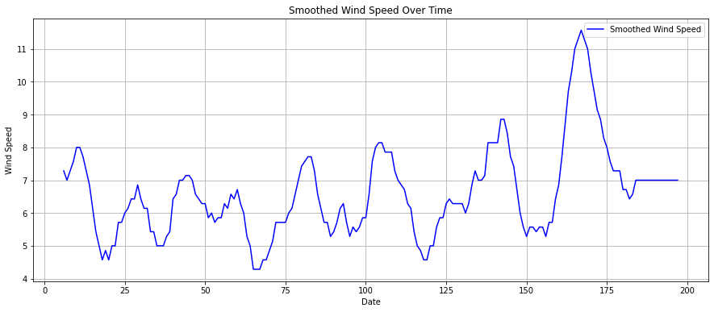

```python
smoothed_wind_speed = future_data['WindSpeed'].rolling(window=7).mean()
plt.figure(figsize=(15, 6))
plt.plot(future_data.index, smoothed_wind_speed, label='Smoothed Wind Speed', color='blue')
plt.xlabel('Date')
plt.ylabel('Wind Speed')
plt.title('Smoothed Wind Speed Over Time')
plt.legend()
plt.grid(True)
plt.show()
```